# Forschungspraktikum 1+2: Computational Social Science

Tutorial 08: Keyword Assisted Topic Models

Dr. Christian Czymara

For comparison, we will continue exploring the [AG News Classification Dataset](https://www.kaggle.com/datasets/amananandrai/ag-news-classification-dataset) data in this tutorial.

## 0. Getting Started

Before we begin, make sure the following R packages are installed and loaded.

- `dplyr` & `magrittr`: For data manipulation
- `quanteda`: For text processing
- `keyATM`: For running keyword assisted topic models

```r
packages <- c("dplyr", "magrittr", "quanteda", "keyATM")

# install if necessary
install.packages(setdiff(packages, rownames(installed.packages())))

# load
lapply(packages, library, character.only = TRUE)
```

```
## [[1]]
## [1] "dplyr"     "stats"     "graphics"  "grDevices" "utils"     "datasets"
## [7] "methods"   "base"
##
## [[2]]
## [1] "magrittr"  "dplyr"     "stats"     "graphics"  "grDevices" "utils"
## [7] "datasets"  "methods"   "base"
##
## [[3]]
##  [1] "quanteda"  "magrittr"  "dplyr"     "stats"     "graphics"  "grDevices"
##  [7] "utils"     "datasets"  "methods"   "base"
##
## [[4]]
##  [1] "keyATM"    "quanteda"  "magrittr"  "dplyr"     "stats"     "graphics"
##  [7] "grDevices" "utils"     "datasets"  "methods"   "base"
```

## 1. Data Preparation

### a) Data Import

We will work with the [same data](https://raw.githubusercontent.com/mhjabreel/CharCnn_Keras/master/data/ag_news_csv/train.csv) and do (almost) the same preprocessing steps. First, again, import the CSV file.

```r
newspaper_data_raw <- read.csv("https://raw.githubusercontent.com/mhjabreel/CharCnn_Keras/master/data/ag_news_csv/train.csv", header = F)
```

### b) Preprocessing

We will prepare the data as in the previous tutorial, with a few changes. First, we will draw a *one percent* random sample (instead of two percent) to urther speed things up. Second, we will not stem the terms, as we will work with unstemmed keywords later. Third, we will remove some additional terms such as “reuters”. Review the code below, then run it:

```r
set.seed(1337)
newspaper_data_sample <- newspaper_data_raw[sample(1:nrow(newspaper_data_raw), size=nrow(newspaper_data_raw)*.01), ]

newspaper_data_sample$title <- newspaper_data_sample$V2
newspaper_data_sample$description <- newspaper_data_sample$V3

newspaper_data_sample %<>%
  mutate(class = recode(V1,
                        `1` = "World",
                        `2` = "Sports",
                        `3` = "Business",
                        `4` = "Sci/Tech"))

newspaper_data_sample$genre <- newspaper_data_sample$class

table(newspaper_data_sample$genre)
```

```
##
## Business Sci/Tech   Sports    World
##      299      282      318      301
```

```r
corpus <- corpus(as.character(newspaper_data_sample$description),
                 docvars = data.frame(genre = newspaper_data_sample$genre
                 ))

# Tokenize
toks <- tokens(corpus, remove_punct = T,
               remove_numbers = T,
               remove_symbols = T,
               remove_separators = T,
               split_hyphens = T,
               remove_url = T,
               include_docvars = T)

toks <- tokens_remove(toks, c(stopwords(source = "stopwords-iso"),
                              "#39", "#151", "reuters", "ap"), case_insensitive = TRUE)

# toks <- tokens_wordstem(toks)

# Create DFM
newspapers_dfm <- dfm(toks)

newspapers_dfm <- newspapers_dfm[!rowSums(newspapers_dfm) == 0, ] # remove empty rows

nrow(newspapers_dfm)
```

```
## [1] 1200
```

```r
ncol(newspapers_dfm)
```

```
## [1] 7141
```

### c) Convert

To use the keyATM package, the DFM must be converted into a `keyATM_docs` object, which is a list of texts. Apply the `keyATM_read()` function to the DFM and save the output in a new object called `keyATM_docs`.

```r
keyATM_docs <- keyATM_read(texts = newspapers_dfm)
```

## 2. Keyword Assisted Topic Modelling

### a) Define Keywords

Before running the model, we need to define they keywords that should underlie the topics. Think about *three topics* that interest you and that might be in the newspaper corpus. For each of the three topics, add *three to five keywords* that should represent it.

```r
keywords <- list(
  germany  = c("germany", "merkel", "berlin", "oktoberfest"),
  olympia   = c("olympic", "gold", "medal", "athletes"),
  ai       = c("artificial", "intelligence", "technology", "software")
  )
```

### b) Run Model

Now that we have prepared the data and defined the keywords, we can run the model. Use the `keyATM()` function to fit a `"base"` model with the *three keyword topics* plus *27 non-keyword topics*. After running the model, use `top_words()` to review the topics. Did your keywords effectively capture the intended topics? What additional themes can you identify among the remaining, non-keyword topics?

```r
k <-  30

key_topics <- keyATM(
  docs              = keyATM_docs,  # text input
  no_keyword_topics = k-3,          # number of topics without keyword topics
  keywords          = keywords,     # keywords
  model             = "base",       # select the model
  options           = list(seed = 1337)
  )

top_words(key_topics)
```

```
##    1_germany   2_olympia           3_ai  Other_1   Other_2    Other_3  Other_4
## 1       quot    gold [✓]   software [✓]     anti     music     google saturday
## 2     united      athens technology [✓]   united     apple government      win
## 3        day       final        company   called      quot      quote  players
## 4        war         cup          users   budget      ipod    profile     real
## 5        u.s   wednesday         online    based   digital    russian baseball
## 6    nuclear olympic [✓]        service   senate      york     search  manager
## 7        afp        team           corp      law    player  announced  leading
## 8   european    olympics       business american   servers    tuesday    goals
## 9      talks   medal [✓]           time      oil computers  officials  spanish
## 10 wednesday         win       security   friday     users   approved   madrid
##         Other_5  Other_6   Other_7   Other_8   Other_9 Other_10 Other_11
## 1          gaza     quot     coach      href broadband  percent   school
## 2       israeli minister      game      york   service     bank  federal
## 3        israel    prime     japan      drug  internet earnings  reserve
```

[output cut: 40 more lines]

### c) Visualizing Topics

Use the `plot_topicprop()` function from keyATM to visualize the prevalence of the three keyword topics in the sample.

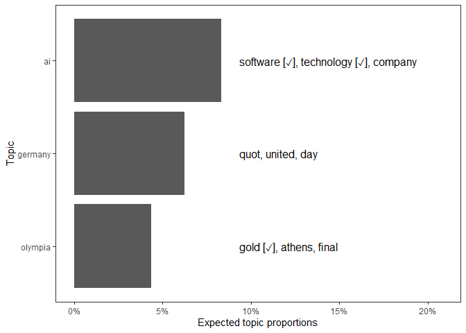

```r
plot_topicprop(key_topics, show_topic = 1:3)
```

### d) Exploring Example Articles

Which articles best represent the three keyword topics? Modify the following base R code to identify them: `data$text[top_docs(key_topics, *X*)[, *Y*]]`. This example retrieves the *X* most probable articles for the *Yth* topic. Adjust the topic index or the number of articles as needed.

```r
# Germany topic
newspaper_data_sample$description[top_docs(key_topics, 10)[, 1]]
```

```
##  [1] "BEIJING (AFP) - Japanese negotiators told North Korea they had  quot;serious concern quot; about its missile program in talks that extended for a second day in Beijing, a Japanese diplomat said."
##  [2] "Reuters - The first test in nearly two years\\of a multibillion-dollar U.S. anti-missile shield failed on\\Wednesday when the interceptor missile shut down as it prepared\\to launch in the central Pacific, the Pentagon said."
##  [3] "RESCUERS in the Philippines yesterday pulled at least four survivors from a building that collapsed in mudslides 10 days ago. The miraculous tale of survival came as officials "
##  [4] "The hot event, who's ahead, pictures and quotes: what you need to know about the US election today."
##  [5] "AFP - New rules being proposed for a reformed United Nations might have allowed the United States and Britain to carry out their invasion of Iraq with the approval of the world body, British Foreign Secretary Jack Straw said in a newspaper interview."
##  [6] "Manila - The Philippines was in the midst of a fiscal crisis and the public should be prepared to make sacrifices, President Gloria Arroyo said yesterday."
##  [7] "The fourth round of the African Union sponsored peace talks on Darfur to find a solution to the 22-months old crisis resumed in Abuja yesterday amidst continued violence in the Sudanese region."
##  [8] "British veterans' groups welcome a US report linking Gulf War syndrome  to toxins, including nerve gas."
##  [9] "Reuters - Three Indian states, including impoverished and crime-ridden Bihar and Jharkhand in the east, will vote in February to elect new legislatures, the Election Commission said on Friday."
## [10] "BRUSSELS (AFP) - Incoming EU executive head Jose Manuel Barroso said he hopes for  quot;clear quot; approval when EU lawmakers finally vote on his new team later this month, to end an unprecedented state of limbo in Brussels."
```

```r
# Olympia topic
newspaper_data_sample$description[top_docs(key_topics, 10)[, 2]]
```

```
##  [1] "MOSCOW - Defending champion Anastasia Myskina upset Lindsay Davenport, and Elena Dementieva defeated Elena Bovina on Saturday to set up the first-ever all-Russian final at the Kremlin Cup."
##  [2] "Athens - Edmonton #39;s Lori-Ann Muenzer moved to within one win of Olympic gold Tuesday, defeating Australian Anna Meares in the semi-final of the sprint cycling."
##  [3] " ATHENS (Reuters) - Australia's Ian Thorpe won the gold  medal in the men's 200 meters freestyle, dubbed the \"race of  the century,\" at the Athens Olympics on Monday."
##  [4] "Georgina Harland comes from 14th place on the final run to win a bronze in the women's modern pentathlon."
##  [5] "AP - Julien Clement of Switzerland shot a 7-under 64 Thursday to take the first-round lead at the Madrid Open."
##  [6] "Spain's Sergio Garcia comes home in 31 to take a one-shot lead at the Volvo Masters."
##  [7] "THE odds are stacked heavily against Lleyton Hewitt but the Australian has incentives aplenty when he faces world No. 1 Roger Federer in the Masters Cup final in Houston today."
##  [8] " ATHENS (Reuters) - Adrenaline junkie Michael Phelps won his  fourth gold medal of the Athens Olympics Thursday and then  complained he was having trouble sleeping."
##  [9] " ATHENS (Reuters) - World 100 meters champion Torri Edwards  will miss the Athens Olympics after her appeal against a  two-year drugs ban was dismissed on Tuesday."
## [10] "England tonight won their first ever Emirates Airline Dubai Sevens title by beating a fiery Fijian side 26-21 in a pulsating final."
```

```r
# AI topic
newspaper_data_sample$description[top_docs(key_topics, 10)[, 3]]
```

```
##  [1] "Hollywood film studios are to sue people who swap pirated copies of films over the internet. The Motion Picture Association of America (MPAA) said the civil suits would seek damages of up to \\$30,000 (16,300) per film."
##  [2] "Lawyers for file-swapping software firm Kazaa have begun their defence in a landmark Australian music piracy case. Kazaa said its software, which allows users to exchange copyrighted music over "
##  [3] "Lionel LLC, a maker of model trains for more than 100 years, has filed for bankruptcy protection after a US jury found the company used designs for toy locomotives stolen from a rival."
##  [4] "Hewlett-Packard next year will take a fresh approach to its utility computing initiative with a product designed to reduce the cost of running corporate computing systems."
##  [5] "LONDON -- Owners of pirated copies of Microsoft Corp. #39;s Windows XP operating system can trade them in for the real thing as part of a bid by the software giant to fight counterfeiting."
##  [6] "McAfee on Monday unveiled a new security service designed to let small companies outsource their e-mail security to the antivirus software maker."
##  [7] "AOL will continue to include Sender ID data in outgoing mail to enable ISPs and others that use it to identify where messages originate."
##  [8] "Customers are able to download full songs with their phone and put them on a computer. Also: Hewlett-Packard has major malfunctions with its software   hellip;. Microsoft and PalmOne, together at last   hellip;. and more."
##  [9] "The deal would end a daring experiment by the nation's airlines, which created Orbitz as a competitor to Expedia and online ticketing sites like it."
## [10] "The individual allegedly barraged Verizon customers with spam that advertised home loans and adult Web sites\\"
```

## 3. Testing for Differences Across Genres

Similar to STM, keyATM enables testing how topic prevalence varies across covariates. Here, we will examine how our keyword topics differ across the `genre` variable.

### a) keyATM Covariates Model

Re-run the model from 2.b) as a `"covariates"` model, incorporating the genre variable (stored in `newspaper_data_sample$genre`) in the `model_settings`.

Once the model is complete, use `top_words()` to review the topics. How do the results compare to those from 2.b)?

```r
key_topics_covar <- keyATM(
  docs              = keyATM_docs,  # text input
  no_keyword_topics = k-3,          # number of topics without keyword topics
  keywords          = keywords,     # keywords
  model             = "covariates",       # select the model
  model_settings    = list(covariates_data    = newspaper_data_sample,
                           covariates_formula = ~ genre),
  options           = list(seed = 1337)
  )

top_words(key_topics_covar)
```

```
##      1_germany     2_olympia           3_ai  Other_1    Other_2    Other_3
## 1         quot      gold [✓]   software [✓]      law       corp       quot
## 2  germany [✓]        athens technology [✓]     anti    popular     region
## 3         data   olympic [✓]           corp     sept     estate   minister
## 4   management      olympics          music    sites      trust     darfur
## 5          aol        sunday        company     card     online  wednesday
## 6        sales        record         online     days      tools        war
## 7         time          race          phone     life      tiger     friday
## 8     continue international            ibm    check     motors    african
## 9        based     medal [✓]       internet shopping       deal      prime
## 10       voice          team        service    spend television government
##    Other_4 Other_5   Other_6      Other_7   Other_8  Other_9   Other_10
## 1   season     sox     union         john     sales     game        oil
## 2    games  boston  european        kerry    demand    miami    tuesday
## 3    night     red     japan         bush announced    night  president
```

[output cut: 40 more lines]

```r
covariates_info(key_topics_covar)
```

```
## Colnames: (Intercept), genreSci/Tech, genreSports, genreWorld
## Standardization: non-factor
## Formula: ~ genre
##
## Preview:
##        (Intercept) genreSci/Tech genreSports genreWorld
## 102547           1             0           0          1
## 95281            1             1           0          0
## 87250            1             0           0          0
## 83960            1             0           0          1
## 9572             1             1           0          0
## 78249            1             1           0          0
```

### b) Estimating Differences

Using the model from 3.a), apply keyATM’s `by_strata_DocTopic()` function to estimate the document-topic distribution by covariate levels. For clarity, focus on *one* of the four genres (e.g., `"genreWorld"`, `"genreSports"`, etc.) for this comparison.

```r
strata_topic <- by_strata_DocTopic(
  key_topics_covar,
  by_var = "genreSports",
  labels = c("Other", "Sports")
  )
```

### c) Visualizing Differences by Topics

Use the `plot()` function to visualize the results from 3.b) for the three keyword topics. Analyze the plot to understand how the prevalence of these topics varies across the selected genre. What patterns or differences can you observe?

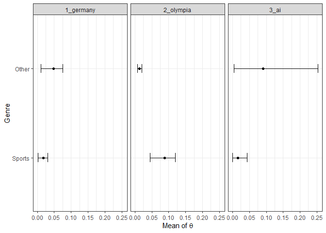

```r
plot(strata_topic, var_name = "Genre",
     show_topic = c(1:3))
```

### d) Visualizing Differences by Covariate

Instead of plotting the results for each topic (as in 3.c)), you can visualize them by covariate levels by adding `, by = "covariate"` to the `plot()` function. Compare these results to those from 3.c). What insights emerge when viewing the data by covariate levels?

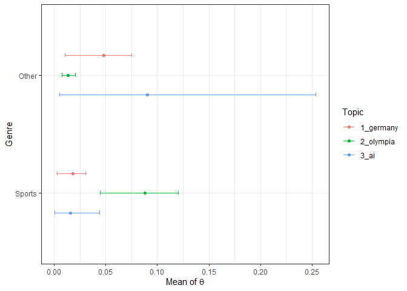

```r
plot(strata_topic, var_name = "Genre",
  show_topic = c(1:3), by = "covariate")
```